# Estimation of FRET efficiency for emission from quantum dots and absorption by diamond NV- center.

```python
import math
import numpy as np
import matplotlib.pyplot as plt
import IPython.display
```

## quantum dot emission spectra

From [Meiling et al. 2018](https://doi.org/10.1021/acs.jpcc.7b12345) we have Figure 2 showing the steady-state photoluminescence emission spectroscopy:

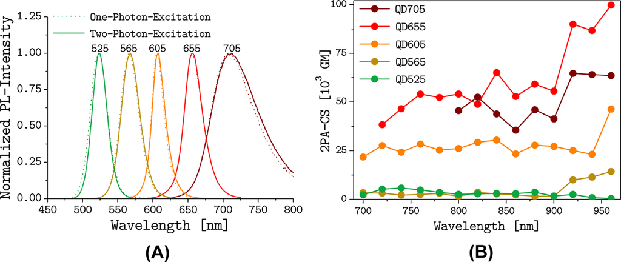

```python
IPython.display.Image(filename="meiling2018fig2.png")
```

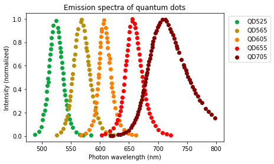

```python
qd525_nm, qd525_intensity = np.loadtxt("QD525.csv", delimiter=',', unpack=True)
qd565_nm, qd565_intensity = np.loadtxt("QD565.csv", delimiter=',', unpack=True)
qd605_nm, qd605_intensity = np.loadtxt("QD605.csv", delimiter=',', unpack=True)
qd655_nm, qd655_intensity = np.loadtxt("QD655.csv", delimiter=',', unpack=True)
qd705_nm, qd705_intensity = np.loadtxt("QD705.csv", delimiter=',', unpack=True)
plt.clf()
plt.scatter(qd525_nm, qd525_intensity, label="QD525", color="#0BA440")
plt.scatter(qd565_nm, qd565_intensity, label="QD565", color="#BB8E0A")
plt.scatter(qd605_nm, qd605_intensity, label="QD605", color="#FF8001")
plt.scatter(qd655_nm, qd655_intensity, label="QD655", color="#FF0000")
plt.scatter(qd705_nm, qd705_intensity, label="QD705", color="#800000")

plt.title("Emission spectra of quantum dots")
plt.xlabel("Photon wavelength (nm)")
plt.ylabel("Intensity (normalized)")
plt.legend(loc="upper right", bbox_to_anchor=(1.25,1));
```

## NV- center absorption spectrum

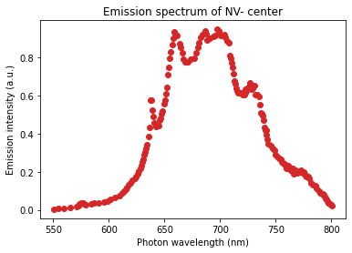

```python
nv_center_emission_nm, nv_center_emission_intensity, _, _, _, _ = np.loadtxt("../ws2_diamond_fret/NV_center_emission.txt", unpack=True)
plt.clf()
plt.scatter(nv_center_emission_nm, nv_center_emission_intensity,color="tab:red")
plt.title("Emission spectrum of NV- center")
plt.xlabel("Photon wavelength (nm)")
plt.ylabel("Emission intensity (a.u.)");
```

> Figure 7 displays the emission spectra of the (N-V)⁻ centers excited by 532 and 1064 nm laser pulses at room temperature for a sample prepared with the 3 MeV proton irradiation. Both spectra were collected at an excitation time of 4 s using a 40× microscope objective with an incident laser power of 0.08 μW and 4.6 mW for the one-photon and two-photon excitations, respectively. In addition to the ZPL of the (N-V)⁻ center at 637 nm, a sharp ZPL derived from the (N-V)⁰ center can be found at 575 nm (2.156 eV) in both spectra. Interestingly, this center cannot be identified in the absorption spectrum even at 80 K (Figure 6b) but reveals itself clearly in the emission profile.

Since this is the emission spectrum of the diamond NV- center, not the absorption / excitation spectrum, we will need to flip the spectrum around the zero phonon line at 637 nm to approximate the absorption spectrum.

```python
nv_center_absorption_nm = 637 - (nv_center_emission_nm - 637)
```

```
The PostScript backend does not support transparency; partially transparent artists will be rendered opaque.
The PostScript backend does not support transparency; partially transparent artists will be rendered opaque.
```

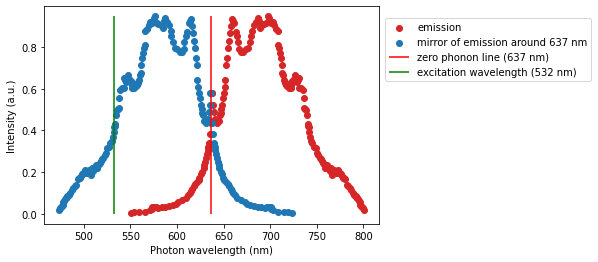

```python
plt.clf()
plt.scatter(nv_center_emission_nm, nv_center_emission_intensity, label="emission", color="tab:red")
plt.scatter(nv_center_absorption_nm, nv_center_emission_intensity, label="mirror of emission around 637 nm", color="tab:blue")
plt.vlines(x=637, ymin=0, ymax=max(nv_center_emission_intensity), color="red", label="zero phonon line (637 nm)")
plt.vlines(x=532, ymin=0, ymax=max(nv_center_emission_intensity), color="green", label="excitation wavelength (532 nm)")
plt.legend(loc="center right", bbox_to_anchor=(1.65,0.8))
plt.xlabel("Photon wavelength (nm)")
plt.ylabel("Intensity (a.u.)")
plt.savefig("NV_emission_flipped_around_ZPL.eps", bbox_inches="tight")
plt.savefig("NV_emission_flipped_around_ZPL.png", dpi=300, bbox_inches="tight")
plt.show()
```

Compare the [image](https://commons.wikimedia.org/wiki/File:NVple.JPG) from the [Wikipedia page for NV centers](https://en.wikipedia.org/wiki/Nitrogen-vacancy_center):

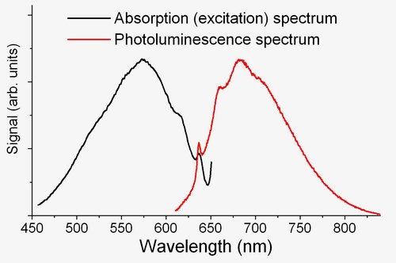

```python
IPython.display.Image(filename="../nv-center-excitation-spectrum/NVple.JPG")
```

The NV- spectrum has a one-photon absorption cross section specified at 532 nm, so we should normalize the spectrum so that it has the correct absorption at that value.

```python
i_closest_to_532nm = np.abs(532 - nv_center_absorption_nm).argmin()
intensity_closest_to_532nm = nv_center_emission_intensity[i_closest_to_532nm]
nv_center_absorption_intensity = nv_center_emission_intensity/intensity_closest_to_532nm
```

```
The PostScript backend does not support transparency; partially transparent artists will be rendered opaque.
The PostScript backend does not support transparency; partially transparent artists will be rendered opaque.
```

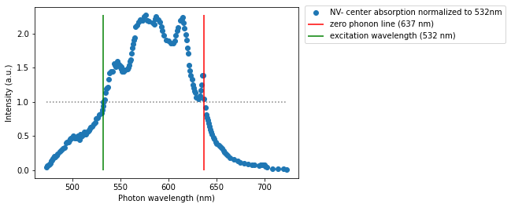

```python
plt.clf()
plt.hlines(y=1.0, xmin=min(nv_center_absorption_nm), xmax=max(nv_center_absorption_nm), color="gray", linestyles="dotted")
plt.scatter(nv_center_absorption_nm, nv_center_absorption_intensity, color="tab:blue", label="NV- center absorption normalized to 532nm")
plt.vlines(x=637, ymin=0, ymax=max(nv_center_absorption_intensity), color="red", label="zero phonon line (637 nm)")
plt.vlines(x=532, ymin=0, ymax=max(nv_center_absorption_intensity), color="green", label="excitation wavelength (532 nm)")
plt.legend(loc="center right", bbox_to_anchor=(1.8,0.9))
plt.xlabel("Photon wavelength (nm)")
plt.ylabel("Intensity (a.u.)")
plt.savefig("NV_absorption_normalized.eps", bbox_inches="tight")
plt.savefig("NV_absorption_normalized.png", dpi=300, bbox_inches="tight")
plt.show()
```

Now let's see what the quantum dot emission spectra look like overlaid on the NV- center absorption spectrum.

```
The PostScript backend does not support transparency; partially transparent artists will be rendered opaque.
The PostScript backend does not support transparency; partially transparent artists will be rendered opaque.
```

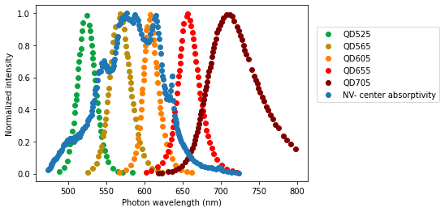

```python
plt.clf()
plt.scatter(qd525_nm, qd525_intensity, label="QD525", color="#0BA440")
plt.scatter(qd565_nm, qd565_intensity, label="QD565", color="#BB8E0A")
plt.scatter(qd605_nm, qd605_intensity, label="QD605", color="#FF8001")
plt.scatter(qd655_nm, qd655_intensity, label="QD655", color="#FF0000")
plt.scatter(qd705_nm, qd705_intensity, label="QD705", color="#800000")
plt.scatter(nv_center_absorption_nm, nv_center_absorption_intensity/nv_center_absorption_intensity.max(), color="tab:blue", label="NV- center absorptivity")
plt.xlabel("Photon wavelength (nm)")
plt.legend(loc="best", bbox_to_anchor=(1.5,0.9))
plt.ylabel("Normalized intensity")
plt.savefig("NV_QD_all_spectra.eps", bbox_inches="tight")
plt.savefig("NV_QD_all_spectra.png", dpi=300, bbox_inches="tight")
plt.show()
```

## Overlap integral

```python
def overlap_OLI(
        donor_lambda,
        donor_fluorescence,
        acceptor_lambda,
        acceptor_extinction,
        molar_attenuation_coefficient):
    # In this method, we run over donor lambdas.
    assert len(donor_lambda) == len(donor_fluorescence)
    assert len(acceptor_lambda) == len(acceptor_extinction)
    # Peak-normalize donor fluorescence.
    donor_norm = donor_fluorescence/donor_fluorescence.max()
    # Peak-normalize acceptor.
    acceptor_norm = acceptor_extinction/acceptor_extinction.max()
    # Only go over the overlapping lambda range.
    lambda_min = max(donor_lambda.min(),acceptor_lambda.min())
    lambda_max = min(donor_lambda.max(),acceptor_lambda.max())
    wavelengths = []
    J_raw = []
    for i, wavelength_nm in enumerate(donor_lambda):
        if wavelength_nm < lambda_min:
            continue
        elif wavelength_nm > lambda_max:
            continue
        wavelengths.append(wavelength_nm)
        f_D = donor_norm[i]
        # Find index of closest corresponding wavelength in acceptor_lambda.
        # TODO: issue a warning if the acceptor data is too sparse.
        j = np.abs(acceptor_lambda - wavelength_nm).argmin()
        # eps_A has units of 1/(M cm)
        eps_A = acceptor_norm[j]*molar_attenuation_coefficient
        # OLI is 10^14 M^-1 cm^-1 nm^4
        J_val = 1e-14 * f_D * eps_A * (wavelength_nm**4)
        J_raw.append(J_val)
    lambda_J = np.array(wavelengths)
    J = np.array(J_raw) / donor_norm.sum()
    return lambda_J, J
```

We need to relate the absorption cross section $\sigma$ of an NV- center to the molar attenuation coefficient $\epsilon_A$.

$$\epsilon_A = \frac{N_A}{\ln 10} \sigma$$

```python
nv_center_absorption_cross_section = 3.1e-17 # cm^2/defect
N_A = 6.02214076e23 # defect/mol
molar_attenuation_coefficient_raw = N_A*nv_center_absorption_cross_section/math.log(10) # cm^2/mol
cm2_per_mol_to_inverse_molar_cm = 1/1000.
molar_attenuation_coefficient = molar_attenuation_coefficient_raw*cm2_per_mol_to_inverse_molar_cm # 1/(M cm)
print("{:.3g} M^-1 cm^-1".format(molar_attenuation_coefficient))
```

```
8.11e+03 M^-1 cm^-1
```

Now that we know the molar attenuation coefficient, we can calculate the overlap with the proper units for each quantum dot.

```python
lambda_J_525, J_OLI_525 = overlap_OLI(
    qd525_nm,
    qd525_intensity,
    nv_center_absorption_nm,
    nv_center_absorption_intensity,
    molar_attenuation_coefficient)

lambda_J_565, J_OLI_565 = overlap_OLI(
    qd565_nm,
    qd565_intensity,
    nv_center_absorption_nm,
    nv_center_absorption_intensity,
    molar_attenuation_coefficient)

lambda_J_605, J_OLI_605 = overlap_OLI(
    qd605_nm,
    qd605_intensity,
    nv_center_absorption_nm,
    nv_center_absorption_intensity,
    molar_attenuation_coefficient)

lambda_J_655, J_OLI_655 = overlap_OLI(
    qd655_nm,
    qd655_intensity,
    nv_center_absorption_nm,
    nv_center_absorption_intensity,
    molar_attenuation_coefficient)

lambda_J_705, J_OLI_705 = overlap_OLI(
    qd705_nm,
    qd705_intensity,
    nv_center_absorption_nm,
    nv_center_absorption_intensity,
    molar_attenuation_coefficient)
```

```python
J_sum_OLI_525 = J_OLI_525.sum()
print("J_525 = {:.4g} * 10^14 M^-1 cm^-1 nm^4 (OLI)".format(J_sum_OLI_525))

J_sum_OLI_565 = J_OLI_565.sum()
print("J_565 = {:.4g} * 10^14 M^-1 cm^-1 nm^4 (OLI)".format(J_sum_OLI_565))

J_sum_OLI_605 = J_OLI_605.sum()
print("J_605 = {:.4g} * 10^14 M^-1 cm^-1 nm^4 (OLI)".format(J_sum_OLI_605))

J_sum_OLI_655 = J_OLI_655.sum()
print("J_655 = {:.4g} * 10^14 M^-1 cm^-1 nm^4 (OLI)".format(J_sum_OLI_655))

J_sum_OLI_705 = J_OLI_705.sum()
print("J_705 = {:.3g} * 10^14 M^-1 cm^-1 nm^4 (OLI)".format(J_sum_OLI_705))
```

```
J_525 = 2.287 * 10^14 M^-1 cm^-1 nm^4 (OLI)
J_565 = 7.246 * 10^14 M^-1 cm^-1 nm^4 (OLI)
J_605 = 9.409 * 10^14 M^-1 cm^-1 nm^4 (OLI)
J_655 = 2.325 * 10^14 M^-1 cm^-1 nm^4 (OLI)
J_705 = 0.399 * 10^14 M^-1 cm^-1 nm^4 (OLI)
```

```
The PostScript backend does not support transparency; partially transparent artists will be rendered opaque.
The PostScript backend does not support transparency; partially transparent artists will be rendered opaque.
```

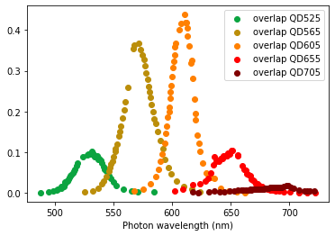

```python
plt.clf()
plt.scatter(lambda_J_525, J_OLI_525, label="overlap QD525", color="#0BA440")
plt.scatter(lambda_J_565, J_OLI_565, label="overlap QD565", color="#BB8E0A")
plt.scatter(lambda_J_605, J_OLI_605, label="overlap QD605", color="#FF8001")
plt.scatter(lambda_J_655, J_OLI_655, label="overlap QD655", color="#FF0000")
plt.scatter(lambda_J_705, J_OLI_705, label="overlap QD705", color="#800000")
plt.legend()
plt.xlabel("Photon wavelength (nm)")
plt.savefig("QD_NV_overlap_all.eps", bbox_inches="tight")
plt.savefig("QD_NV_overlap_all.png", dpi=300, bbox_inches="tight")
plt.show()
```

## Förster distance

Now that we have the overlap integral, we can calculate the Förster distance from a few other parameters of the host material.

```python
def forster_distance_OLI(kappa2, Phi_D, J, n):
    R6_0 = kappa2*Phi_D*J/(n**4)
    R_0 = 4.542*(R6_0)**(1./6.) # nm
    return R_0
```

Recall $$ R_0^6 = \frac{9 (\ln 10) \kappa^2 \Phi_D J }{128\pi^5 n^4 N_A} $$ which for OLI units is $$ R_0 = 4.542 \left(\frac{\kappa^2 \Phi_D J }{n^4}\right)^{1/6} $$

# Break-even point

The FRET efficiency drops off as a function of distance, and once we reach the distance where the FRET efficiency is the ratio of the absorption coefficients, i.e. $\approx 1 \times 10^{-4}$, then we have reached the "break-even" point where FRET becomes equally as inefficient as direct excitation.

To do this, we will need $r_{DA}$ in terms of $E$ and $R_0$, i.e.

$$ r_{DA} = R_0 \left(\frac{1-E}{E}\right)^{1/6} $$

```python
def get_r_DA(E, R_0):
    return R_0*((1-E)/E)**(1./6.)
```

We will also need $E$ from the ratio of the two-photon cross sections,

$$ E = \frac{ \sigma^{(2)}_{A}} { \sigma^{(2)}_{B}} $$ where $\sigma^{(2)}_{A}$ and $\sigma^{(2)}_{B}$ are the two-photon absorption cross-sections of the NV-center and the quantum dots respectively, generally in units of $\mathrm{cm^4 s/photon}$. Note that $\sigma^{(2)}$ depends on the wavelength.

From [Wee et al. 2007](https://doi.org/10.1021/jp073938o) we have $\sigma^{(2)}_{A} = (0.45 \pm 0.23) \times 10^{-50} \mathrm{cm^4} \cdot \mathrm{s / photon}$ for the NV center, measured at a wavelengths of 1064 nm against a Rhodamine B standard.

```python
sigma_TPA_NV = 0.45 # 1e-50 cm^4 s/photon
print("σ_TPA_NV- = {} × 10⁻⁵⁰ cm⁴ s/photon".format(sigma_TPA_NV))
```

```
σ_TPA_NV- = 0.45 × 10⁻⁵⁰ cm⁴ s/photon
```

From the supplemental information for [Meiling et al. 2018](https://doi.org/10.1021/acs.jpcc.7b12345) we choose the largest two-photon cross-section for each type of quantum dot.

Table S5: Two-photon absorption cross-sections $σ_{2PA}$ of fluorescein<sup>2</sup> and the examined QDs, at selected wavelengths, in Goeppert-Mayer units (1 GM = $10^{-50} \mathrm{cm}^4 \, \mathrm{s} \, \mathrm{photon}^{-1}$). Fluorescein in aqueous NaOH (pH 12) and QDs in 50 mM borate buffer (Qdot® Incubation buffer).

| λ_ex | Fluorescein<sup>2</sup> | QD525 | QD565 | QD605 | QD655 | QD705 |
| --- | --- | --- | --- | --- | --- | --- |
| 700 | 19 | 2400 | 12700 | 21600 | - | - |
| 720 | 19 | 5200 | 8400 | 27000 | 32900 | - |
| 740 | 30 | 5800 | 8700 | 23100 | 42300 | - |
| 760 | 36 | 4800 | 9500 | 29800 | 47700 | - |
| 780 | 37 | 3500 | 9900 | 26400 | 45500 | - |
| 800 | 36 | 2600 | 10800 | 26900 | 58300 | 45600 |
| 820 | 29 | 2800 | 11500 | 29800 | 55400 | 43500 |
| 840 | 13 | 3000 | 9500 | 30500 | 60500 | 43800 |
| 860 | 8 | 3300 | 7100 | 25700 | 48200 | 39800 |
| 880 | 11 | 3600 | 6600 | 27000 | 56500 | 46000 |
| 900 | 16 | 1700 | 5900 | 26400 | 52200 | 41300 |
| 920 | 26 | 2500 | 10000 | 24600 | 89900 | 64700 |
| 940 | 21 | 870 | 11400 | 23300 | 86700 | 64100 |
| 960 | 15 | 420 | 14300 | 47900 | 99800 | 63500 |

```python
absorp_QD525 = {
    700 : 2400,
    720 : 5200,
    740 : 5800,
    760 : 4800,
    780 : 3500,
    800 : 2600,
    820 : 2800,
    840 : 3000,
    860 : 3300,
    880 : 3600,
    900 : 1700,
    920 : 2500,
    940 : 870,
    960 : 420
}
absorp_QD565 = {
    700 : 12700,
    720 : 8400 ,
    740 : 8700 ,
    760 : 9500 ,
    780 : 9900 ,
    800 : 10800,
    820 : 11500,
    840 : 9500 ,
    860 : 7100 ,
    880 : 6600 ,
    900 : 5900 ,
    920 : 10000,
    940 : 11400,
    960 : 14300,
}
absorp_QD605 = {
    700 : 21600,
    720 : 27000,
    740 : 23100,
    760 : 29800,
    780 : 26400,
    800 : 26900,
    820 : 29800,
    840 : 30500,
    860 : 25700,
    880 : 27000,
    900 : 26400,
    920 : 24600,
    940 : 23300,
    960 : 47900,
}
absorp_QD655 = {
    720 : 32900,
    740 : 42300,
    760 : 47700,
    780 : 45500,
    800 : 58300,
    820 : 55400,
    840 : 60500,
    860 : 48200,
    880 : 56500,
    900 : 52200,
    920 : 89900,
    940 : 86700,
    960 : 99800,
}
absorp_QD705 = {
    800 : 45600,
    820 : 43500,
    840 : 43800,
    860 : 39800,
    880 : 46000,
    900 : 41300,
    920 : 64700,
    940 : 64100,
    960 : 63500,
}
```

We can assume the $\sigma^{(2)}_{A}$ for the NV- center does not change much with wavelength, and tune to the excitation wavelength that gives the largest two-photon absorption cross-section for each type of quantum dot. For most of them, this is at the largest measured wavelength (960 nm).

```python
absorp_QD525_max_nm = max(absorp_QD525, key=absorp_QD525.get)
absorp_QD565_max_nm = max(absorp_QD565, key=absorp_QD565.get)
absorp_QD605_max_nm = max(absorp_QD605, key=absorp_QD605.get)
absorp_QD655_max_nm = max(absorp_QD655, key=absorp_QD655.get)
absorp_QD705_max_nm = max(absorp_QD705, key=absorp_QD705.get)
```

```python
sigma_TPA_QD525 = max(absorp_QD525.values())
sigma_TPA_QD565 = max(absorp_QD565.values())
sigma_TPA_QD605 = max(absorp_QD605.values())
sigma_TPA_QD655 = max(absorp_QD655.values())
sigma_TPA_QD705 = max(absorp_QD705.values())
```

```python
print("Type\tλ (nm)\tσ_2PA (GM)")
print("QD525\t{}\t{}".format(absorp_QD525_max_nm, sigma_TPA_QD525))
print("QD565\t{}\t{}".format(absorp_QD565_max_nm, sigma_TPA_QD565))
print("QD605\t{}\t{}".format(absorp_QD605_max_nm, sigma_TPA_QD605))
print("QD655\t{}\t{}".format(absorp_QD655_max_nm, sigma_TPA_QD655))
print("QD705\t{}\t{}".format(absorp_QD705_max_nm, sigma_TPA_QD705))
```

```
Type	λ (nm)	σ_2PA (GM)
QD525	740	5800
QD565	960	14300
QD605	960	47900
QD655	960	99800
QD705	920	64700
```

For comparison, note that WS<sub>2</sub> has $σ_{2PA}$ = 10,000 GM at 1030 nm. (See other notebook/HTML for calculations and [source](https://doi.org/10.1021/acsnano.5b03480).)

```python
# quantum yield of the quantum dots varies,
# so choose a range and plot it instead of using a single value.
Phi_D_range = np.linspace(0.01, 1.0, num=100, endpoint=True)

kappa2 = 2./3 # orientation factor for dipole interaction
# "The orientation factor takes on a value of κ² = 2/3 for a dynamic and
# isotropic distribution of donor and acceptor orientations"
# "Varies between 0 and 4."

n_diamond = 2.417 # index of refraction of diamond
# We will assume this doesn't vary much with wavelength.
# TODO: check this assumption for 740, 920, 960 nm.
```

```python
R_0_nm_range_525 = forster_distance_OLI(kappa2, Phi_D_range, J = J_sum_OLI_525, n = n_diamond)
R_0_nm_range_565 = forster_distance_OLI(kappa2, Phi_D_range, J = J_sum_OLI_565, n = n_diamond)
R_0_nm_range_605 = forster_distance_OLI(kappa2, Phi_D_range, J = J_sum_OLI_605, n = n_diamond)
R_0_nm_range_655 = forster_distance_OLI(kappa2, Phi_D_range, J = J_sum_OLI_655, n = n_diamond)
R_0_nm_range_705 = forster_distance_OLI(kappa2, Phi_D_range, J = J_sum_OLI_705, n = n_diamond)
```

```python
E_ratio_525 = sigma_TPA_NV / sigma_TPA_QD525
E_ratio_565 = sigma_TPA_NV / sigma_TPA_QD565
E_ratio_605 = sigma_TPA_NV / sigma_TPA_QD605
E_ratio_655 = sigma_TPA_NV / sigma_TPA_QD655
E_ratio_705 = sigma_TPA_NV / sigma_TPA_QD705
```

```python
r_DA_breakeven_525 = get_r_DA(E_ratio_525, R_0_nm_range_525)
r_DA_breakeven_565 = get_r_DA(E_ratio_565, R_0_nm_range_565)
r_DA_breakeven_605 = get_r_DA(E_ratio_605, R_0_nm_range_605)
r_DA_breakeven_655 = get_r_DA(E_ratio_655, R_0_nm_range_655)
r_DA_breakeven_705 = get_r_DA(E_ratio_705, R_0_nm_range_705)
```

```
The PostScript backend does not support transparency; partially transparent artists will be rendered opaque.
The PostScript backend does not support transparency; partially transparent artists will be rendered opaque.
```

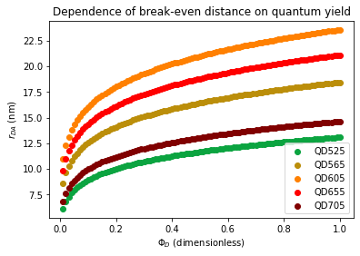

```python
plt.clf()
plt.scatter(Phi_D_range, r_DA_breakeven_525, color="#0BA440", label="QD525")
plt.scatter(Phi_D_range, r_DA_breakeven_565, color="#BB8E0A", label="QD565")
plt.scatter(Phi_D_range, r_DA_breakeven_605, color="#FF8001", label="QD605")
plt.scatter(Phi_D_range, r_DA_breakeven_655, color="#FF0000", label="QD655")
plt.scatter(Phi_D_range, r_DA_breakeven_705, color="#800000", label="QD705")
plt.legend()
plt.title("Dependence of break-even distance on quantum yield")
plt.xlabel("$\Phi_D$ (dimensionless)")
plt.ylabel("$r_{DA}$ (nm)")
plt.savefig("break-even_distance.eps", bbox_inches="tight")
plt.savefig("break-even_distance.png", dpi=300, bbox_inches="tight")
plt.show()
```

# Appendix

Public git repository for this notebook: https://github.com/nbeaver/ws2-diamond-fret-calculation